# Estimates for Netherlands

Identifying changes in the reproduction number, rate of spread, and doubling time during the course of the COVID-19 outbreak whilst accounting for potential biases due to delays in case reporting in Netherlands.

## Summary (estimates as of the 2020-03-21)

|  | Estimate |
| --- | --- |
| New infections | 1266 (420 – 2185) |
| Expected change in daily cases | Unsure |
| Effective reproduction no. | 1.3 (0.5 – 1.8) |
| Doubling time (days) | 15 (3.9 – Cases decreasing) |
| Adjusted R-squared | 0.67 (-0.17 – 0.99) |

*Table 1: Latest estimates (as of the 2020-03-21) of the number of cases by date of infection, the expected change in daily cases, the effective reproduction number, the doubling time, and the adjusted R-squared of the exponential fit. The mean and 90% credible interval is shown for each numeric estimate.*

## Reported and estimated cases by date of onset and time-varying reproduction number estimates

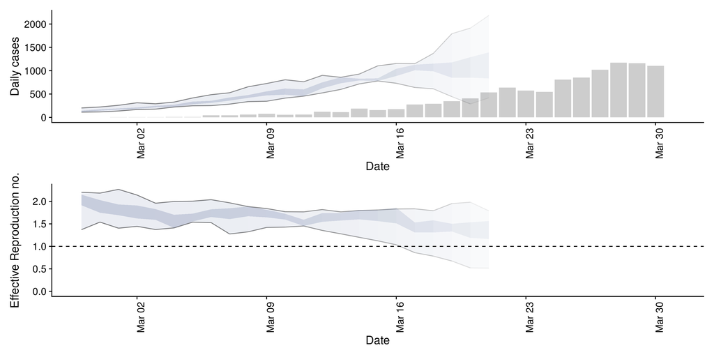

*Figure 1: A.) Cases by date of report (bars) and estimated cases by date of infection. B.) Time-varying estimate of the effective reproduction number. Light grey ribbon = 90% credible interval. Estimates are shown until the 2020-03-21.Dark grey ribbon = 50% credible interval. Confidence in the estimated values is indicated by shading with reduced shading corresponding to reduced confidence.*

## Time-varying rate of spread and doubling time

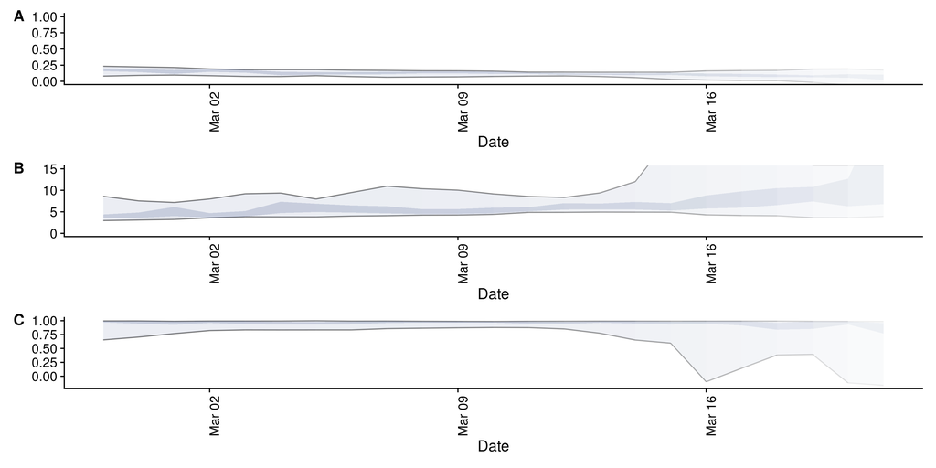

*Figure 2: A.) Time-varying estimate of the rate of spread, B.) Time-varying estimate of the doubling time in days (note that when the rate of spread is negative the doubling time is assumed to be infinite), C.) The adjusted R-squared estimates indicating the goodness of fit of the exponential regression model (with values closer to 1 indicating a better fit). Estimates are shown until the 2020-03-21. Light grey ribbon = 90% credible interval; dark grey ribbon = the 50% credible interval. Confidence in the estimated values is indicated by shading with reduced shading corresponding to reduced confidence.*

Share: